# Part I - (Loan Data from Prosper)

## by Durowoju Oluwadamilola

1. Introduction
2. Preliminary Wrangling
3. Data Cleaning
4. Univariate Exploration
5. Bivariate Exploration
6. Multivariate Exploration
7. Conclusions

## Introduction

Prosper is a peer-to-peer lending marketplace that helps in facilitating loans. This data set contains 113,937 loans with 81 variables on each loan, including loan amount, borrower rate (or interest rate), current loan status, borrower income, and many others. This [Sheet](https://docs.google.com/spreadsheets/d/1gDyi_L4UvIrLTEC6Wri5nbaMmkGmLQBk-Yx3z0XDEtI/edit#gid=0) contains information about the dataset variables.

## Preliminary Wrangling

```python
# import all packages and set plots to be embedded inline
import numpy as np
import pandas as pd
import matplotlib.pyplot as plt
import seaborn as sb

%matplotlib inline
```

```python
# load dataset into a pandas dataframe
loan_data = pd.read_csv('prosperLoanData.csv')
```

```python
# retrieve the first five rows and display all columns
with pd.option_context('display.max_columns', None):
    display(loan_data.head())
```

|  | ListingKey | ListingNumber | ListingCreationDate | CreditGrade | Term | LoanStatus | ClosedDate | BorrowerAPR | BorrowerRate | LenderYield | EstimatedEffectiveYield | EstimatedLoss | EstimatedReturn | ProsperRating (numeric) | ProsperRating (Alpha) | ProsperScore | ListingCategory (numeric) | BorrowerState | Occupation | EmploymentStatus | EmploymentStatusDuration | IsBorrowerHomeowner | CurrentlyInGroup | GroupKey | DateCreditPulled | CreditScoreRangeLower | CreditScoreRangeUpper | FirstRecordedCreditLine | CurrentCreditLines | … |
| --- | --- | --- | --- | --- | --- | --- | --- | --- | --- | --- | --- | --- | --- | --- | --- | --- | --- | --- | --- | --- | --- | --- | --- | --- | --- | --- | --- | --- | --- | --- |
| 0 | 1021339766868145413AB3B | 193129 | 2007-08-26 19:09:29.263000000 | C | 36 | Completed | 2009-08-14 00:00:00 | 0.16516 | 0.1580 | 0.1380 | NaN | NaN | NaN | NaN | NaN | NaN | 0 | CO | Other | Self-employed | 2.0 | True | True | NaN | 2007-08-26 18:41:46.780000000 | 640.0 | 659.0 | 2001-10-11 00:00:00 | 5.0 | … |
| 1 | 10273602499503308B223C1 | 1209647 | 2014-02-27 08:28:07.900000000 | NaN | 36 | Current | NaN | 0.12016 | 0.0920 | 0.0820 | 0.07960 | 0.0249 | 0.05470 | 6.0 | A | 7.0 | 2 | CO | Professional | Employed | 44.0 | False | False | NaN | 2014-02-27 08:28:14 | 680.0 | 699.0 | 1996-03-18 00:00:00 | 14.0 | … |
| 2 | 0EE9337825851032864889A | 81716 | 2007-01-05 15:00:47.090000000 | HR | 36 | Completed | 2009-12-17 00:00:00 | 0.28269 | 0.2750 | 0.2400 | NaN | NaN | NaN | NaN | NaN | NaN | 0 | GA | Other | Not available | NaN | False | True | 783C3371218786870A73D20 | 2007-01-02 14:09:10.060000000 | 480.0 | 499.0 | 2002-07-27 00:00:00 | NaN | … |
| 3 | 0EF5356002482715299901A | 658116 | 2012-10-22 11:02:35.010000000 | NaN | 36 | Current | NaN | 0.12528 | 0.0974 | 0.0874 | 0.08490 | 0.0249 | 0.06000 | 6.0 | A | 9.0 | 16 | GA | Skilled Labor | Employed | 113.0 | True | False | NaN | 2012-10-22 11:02:32 | 800.0 | 819.0 | 1983-02-28 00:00:00 | 5.0 | … |
| 4 | 0F023589499656230C5E3E2 | 909464 | 2013-09-14 18:38:39.097000000 | NaN | 36 | Current | NaN | 0.24614 | 0.2085 | 0.1985 | 0.18316 | 0.0925 | 0.09066 | 3.0 | D | 4.0 | 2 | MN | Executive | Employed | 44.0 | True | False | NaN | 2013-09-14 18:38:44 | 680.0 | 699.0 | 2004-02-20 00:00:00 | 19.0 | … |

```python
# Get the no of rows and columns
loan_data.shape
```

```
(113937, 81)
```

```python
# descriptive information about the dataset
loan_data.info()
```

```
<class 'pandas.core.frame.DataFrame'>
RangeIndex: 113937 entries, 0 to 113936
Data columns (total 81 columns):
 #   Column                               Non-Null Count   Dtype
---  ------                               --------------   -----
 0   ListingKey                           113937 non-null  object
 1   ListingNumber                        113937 non-null  int64
 2   ListingCreationDate                  113937 non-null  object
 3   CreditGrade                          28953 non-null   object
 4   Term                                 113937 non-null  int64
 5   LoanStatus                           113937 non-null  object
 6   ClosedDate                           55089 non-null   object
 7   BorrowerAPR                          113912 non-null  float64
 8   BorrowerRate                         113937 non-null  float64
 9   LenderYield                          113937 non-null  float64
```

[output cut: 73 more lines]

```python
loan_data.describe()
```

|  | ListingNumber | Term | BorrowerAPR | BorrowerRate | LenderYield | EstimatedEffectiveYield | EstimatedLoss | EstimatedReturn | ProsperRating (numeric) | ProsperScore | ... | LP_ServiceFees | LP_CollectionFees | LP_GrossPrincipalLoss | LP_NetPrincipalLoss | LP_NonPrincipalRecoverypayments | PercentFunded | Recommendations | InvestmentFromFriendsCount | InvestmentFromFriendsAmount | Investors |
| --- | --- | --- | --- | --- | --- | --- | --- | --- | --- | --- | --- | --- | --- | --- | --- | --- | --- | --- | --- | --- | --- |
| count | 1.139370e+05 | 113937.000000 | 113912.000000 | 113937.000000 | 113937.000000 | 84853.000000 | 84853.000000 | 84853.000000 | 84853.000000 | 84853.000000 | ... | 113937.000000 | 113937.000000 | 113937.000000 | 113937.000000 | 113937.000000 | 113937.000000 | 113937.000000 | 113937.000000 | 113937.000000 | 113937.000000 |
| mean | 6.278857e+05 | 40.830248 | 0.218828 | 0.192764 | 0.182701 | 0.168661 | 0.080306 | 0.096068 | 4.072243 | 5.950067 | ... | -54.725641 | -14.242698 | 700.446342 | 681.420499 | 25.142686 | 0.998584 | 0.048027 | 0.023460 | 16.550751 | 80.475228 |
| std | 3.280762e+05 | 10.436212 | 0.080364 | 0.074818 | 0.074516 | 0.068467 | 0.046764 | 0.030403 | 1.673227 | 2.376501 | ... | 60.675425 | 109.232758 | 2388.513831 | 2357.167068 | 275.657937 | 0.017919 | 0.332353 | 0.232412 | 294.545422 | 103.239020 |
| min | 4.000000e+00 | 12.000000 | 0.006530 | 0.000000 | -0.010000 | -0.182700 | 0.004900 | -0.182700 | 1.000000 | 1.000000 | ... | -664.870000 | -9274.750000 | -94.200000 | -954.550000 | 0.000000 | 0.700000 | 0.000000 | 0.000000 | 0.000000 | 1.000000 |
| 25% | 4.009190e+05 | 36.000000 | 0.156290 | 0.134000 | 0.124200 | 0.115670 | 0.042400 | 0.074080 | 3.000000 | 4.000000 | ... | -73.180000 | 0.000000 | 0.000000 | 0.000000 | 0.000000 | 1.000000 | 0.000000 | 0.000000 | 0.000000 | 2.000000 |
| 50% | 6.005540e+05 | 36.000000 | 0.209760 | 0.184000 | 0.173000 | 0.161500 | 0.072400 | 0.091700 | 4.000000 | 6.000000 | ... | -34.440000 | 0.000000 | 0.000000 | 0.000000 | 0.000000 | 1.000000 | 0.000000 | 0.000000 | 0.000000 | 44.000000 |
| 75% | 8.926340e+05 | 36.000000 | 0.283810 | 0.250000 | 0.240000 | 0.224300 | 0.112000 | 0.116600 | 5.000000 | 8.000000 | ... | -13.920000 | 0.000000 | 0.000000 | 0.000000 | 0.000000 | 1.000000 | 0.000000 | 0.000000 | 0.000000 | 115.000000 |
| max | 1.255725e+06 | 60.000000 | 0.512290 | 0.497500 | 0.492500 | 0.319900 | 0.366000 | 0.283700 | 7.000000 | 11.000000 | ... | 32.060000 | 0.000000 | 25000.000000 | 25000.000000 | 21117.900000 | 1.012500 | 39.000000 | 33.000000 | 25000.000000 | 1189.000000 |

8 rows × 61 columns

```python
# Check if there are duplicates
loan_data.duplicated().sum()
```

```
0
```

```python
# Check for columns with null values
with pd.option_context('display.max_rows', None):
    display(loan_data.isnull().sum())
```

```
ListingKey                                  0
ListingNumber                               0
ListingCreationDate                         0
CreditGrade                             84984
Term                                        0
LoanStatus                                  0
ClosedDate                              58848
BorrowerAPR                                25
BorrowerRate                                0
LenderYield                                 0
EstimatedEffectiveYield                 29084
EstimatedLoss                           29084
EstimatedReturn                         29084
ProsperRating (numeric)                 29084
ProsperRating (Alpha)                   29084
ProsperScore                            29084
ListingCategory (numeric)                   0
BorrowerState                            5515
Occupation                               3588
EmploymentStatus                         2255
EmploymentStatusDuration                 7625
IsBorrowerHomeowner                         0
CurrentlyInGroup                            0
GroupKey                               100596
DateCreditPulled                            0
CreditScoreRangeLower                     591
CreditScoreRangeUpper                     591
FirstRecordedCreditLine                   697
CurrentCreditLines                       7604
OpenCreditLines                          7604
TotalCreditLinespast7years                697
OpenRevolvingAccounts                       0
OpenRevolvingMonthlyPayment                 0
InquiriesLast6Months                      697
TotalInquiries                           1159
CurrentDelinquencies                      697
AmountDelinquent                         7622
DelinquenciesLast7Years                   990
PublicRecordsLast10Years                  697
PublicRecordsLast12Months                7604
```

[output cut: 27 more lines]

```
MonthlyLoanPayment                          0
LP_CustomerPayments                         0
LP_CustomerPrincipalPayments                0
LP_InterestandFees                          0
LP_ServiceFees                              0
LP_CollectionFees                           0
LP_GrossPrincipalLoss                       0
LP_NetPrincipalLoss                         0
LP_NonPrincipalRecoverypayments             0
PercentFunded                               0
Recommendations                             0
InvestmentFromFriendsCount                  0
InvestmentFromFriendsAmount                 0
Investors                                   0
dtype: int64
```

```python
For some of the columns that have null values, there are some variables used to record loan information before July 2009 while
some other variables (for example, EstimatedLoss, ProsperRating) are used to store loan information after July 2009.
```

## Data Cleaning

I found some columns with wrong datatypes so, I will be fixing them in this section.

```python
# convert object to datetime datatype
loan_data['ListingCreationDate'] = pd.to_datetime(loan_data['ListingCreationDate'])
loan_data['ClosedDate'] = pd.to_datetime(loan_data['ClosedDate'])
loan_data['DateCreditPulled'] = pd.to_datetime(loan_data['DateCreditPulled'])
loan_data['FirstRecordedCreditLine'] = pd.to_datetime(loan_data['FirstRecordedCreditLine'])
loan_data['LoanOriginationDate'] = pd.to_datetime(loan_data['LoanOriginationDate'])
```

```python
# converts float to int while assigning 0 to null columns
def convert_float_to_int(column_name):
    loan_data[column_name] = loan_data[column_name].fillna(0)
    loan_data[column_name] = loan_data[column_name].astype(int)
```

```python
# convert float to int
columns = ['EmploymentStatusDuration', 'CurrentCreditLines', 'OpenCreditLines', 'TotalCreditLinespast7years',
           'OpenRevolvingAccounts', 'OpenRevolvingMonthlyPayment', 'InquiriesLast6Months', 'TotalInquiries',
           'CurrentDelinquencies', 'DelinquenciesLast7Years', 'PublicRecordsLast10Years', 'PublicRecordsLast12Months',
           'TradesNeverDelinquent (percentage)', 'TradesOpenedLast6Months', 'TotalProsperLoans', 'TotalProsperPaymentsBilled',
           'OnTimeProsperPayments', 'TotalProsperPaymentsBilled', 'ProsperPaymentsLessThanOneMonthLate',
           'ProsperPaymentsOneMonthPlusLate', 'TotalProsperPaymentsBilled', 'CreditScoreRangeLower', 'CreditScoreRangeUpper'
          ]

for column in columns:
    convert_float_to_int(column)
```

```python
# convert int to object
loan_data['ListingNumber'] = loan_data['ListingNumber'].astype(str)
```

```python
# rename columns to conform to naming convention
loan_data.rename(columns={'LP_CustomerPayments': 'LPCustomerPayments', 'LP_CustomerPrincipalPayments': 'LPCustomerPrincipalPayments',
                          'LP_InterestandFees': 'LPInterestandFees', 'LP_ServiceFees': 'LPServiceFees','LP_CollectionFees': 'LPCollectionFees',
                          'LP_GrossPrincipalLoss': 'LPGrossPrincipalLoss', 'LP_NetPrincipalLoss': 'LPNetPrincipalLoss',
                          'LP_NonPrincipalRecoverypayments': 'LPNonPrincipalRecoverypayments', 'ProsperRating (Alpha)': 'ProsperRating(Alpha)',
                          'ListingCategory (numeric)': 'ListingCategory(numeric)'}, inplace=True)
```

```python
# convert to category datatype
loan_data['LoanStatus'] = loan_data['LoanStatus'].astype('category')
loan_data['IncomeRange'] = loan_data['IncomeRange'].astype('category')
loan_data['CreditGrade'] = loan_data['CreditGrade'].astype('category')
```

```python
# converts to ordered categorical datatype
def convert_ordinal_dtype(ordinal_var_dict):
    for var in ordinal_var_dict:
        pd_ver = pd.__version__.split(".")
        if (int(pd_ver[0]) > 0) or (int(pd_ver[1]) >= 21): # v0.21 or later
            ordered_var = pd.api.types.CategoricalDtype(ordered = True,
                                                        categories = ordinal_var_dict[var])
            loan_data[var] = loan_data[var].astype(ordered_var)
        else: # pre-v0.21
            loan_data[var] = loan_data[var].astype('category', ordered = True,
                                                 categories = ordinal_var_dict[var])
```

```python
# convert IncomeRange and ProsperRating to ordered cat type
ordinal_var_dict = {'IncomeRange': ['$0', '$1-24,999', '$25,000-49,999', '$50,000-74,999', '$75,000-99,999','$100,000+','Not employed','Not displayed'],
                    'ProsperRating(Alpha)': ['AA', 'A', 'B', 'C', 'D','E','HR']}

convert_ordinal_dtype(ordinal_var_dict)
```

```python
loan_data.replace(to_replace={"ListingCategory(numeric)": {
    0: 'NA', 1: 'Debt Consolidation',
    2: 'Home Improvement', 3: 'Business',
    4: 'Personal Loan', 5: 'Student Use',
    6: 'Auto', 7: 'Other',
    8: "Baby&Adoption", 9: 'Boat',
    10: 'Cosmetic Procedure', 11: 'Engagement Ring',
    12: 'Green Loans', 13: 'Household Expenses',
    14: 'Large Purchases', 15: 'Medical/Dental',
    16: 'Motorcycle', 17: 'RV',
    18: 'Taxes', 19: 'Vacation', 20: 'Wedding Loans'
}}, inplace=True)

loan_data.rename(columns={"ListingCategory(numeric)": "ListingCategory"}, inplace=True)
```

### What is the structure of your dataset?

> It contains 113937 rows and 81 columns. Most of the columns are numeric (float) with some in categories (ordered and unordered). Overall, the dataset needs to be cleaned as there are mixed datatypes in some columns.

### What is/are the main feature(s) of interest in your dataset?

> As an investor, my interest lies with who is likely to repay a loan and who are the major defaulters in loan repayment. I will be investigating factors that are responsible for defaulting in loan repayment.

### What features in the dataset do you think will help support your investigation into your feature(s) of interest?

> Variables relating to income such as occupation,income range, employment status, debtToIncomeRatio and credit history will be of great help.

## Univariate Exploration

#### What are the Occupation of Borrowers?

It would be interesting to know the categories of borrowers on Prosper.

```python
occupation_counts = loan_data['Occupation'].value_counts()
occupation_order = occupation_counts.index
occupation_counts
```

```
Other                          28617
Professional                   13628
Computer Programmer             4478
Executive                       4311
Teacher                         3759
                               ...
Dentist                           68
Student - College Freshman        41
Student - Community College       28
Judge                             22
Student - Technical School        16
Name: Occupation, Length: 67, dtype: int64
```

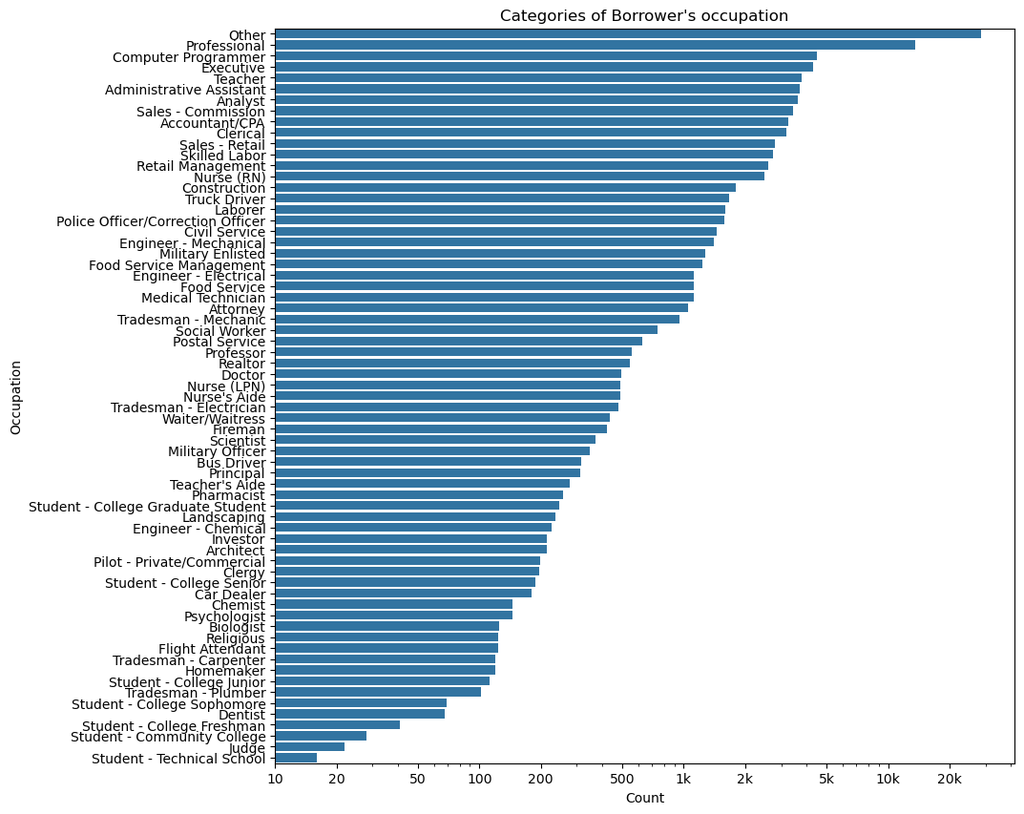

```python
# plot vertical countplot to accomodate the large categories
plt.figure(figsize=(10,10))

base_color = sb.color_palette()[0]
sb.countplot(data=loan_data, y='Occupation', color=base_color, order=occupation_order)
plt.ylabel('Occupation')
plt.xscale('log')
plt.xticks([10,20,50,100,200,500, 1e3, 2e3, 5e3, 1e4, 2e4], [10,20,50,100,200,500, '1k', '2k', '5k', '10k', '20k'])
plt.xlabel('Count')
plt.title("Categories of Borrower's occupation");
```

From the Plot, 'Others' and 'Professional' are the most occupations selected by borrowers at the time they created the listing. This selection is generic as it doesn't reflect a specific occupation. Asides from these two, 'Executive', 'Computer Programmer', 'Administrative Assistant', 'Teacher' are also popular.

#### What is the Employment Status of Borrowers?

```python
status_counts = loan_data['EmploymentStatus'].value_counts()
status_order = status_counts.index
status_counts
```

```
Employed         67322
Full-time        26355
Self-employed     6134
Not available     5347
Other             3806
Part-time         1088
Not employed       835
Retired            795
Name: EmploymentStatus, dtype: int64
```

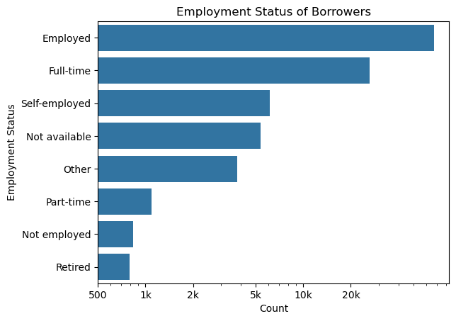

```python
base_color = sb.color_palette()[0]
sb.countplot(data=loan_data, y='EmploymentStatus', color=base_color, order=status_order)
plt.ylabel('Employment Status')
plt.xscale('log')
plt.xticks([500, 1e3, 2e3, 5e3, 1e4, 2e4], [500, '1k', '2k', '5k', '10k', '20k'])
plt.xlabel('Count')
plt.title("Employment Status of Borrowers");
```

I expect that there will be more of Employed persons as it is confirmed in the plot.

#### What is the Income Range of Borrowers?

```python
income_counts = loan_data['IncomeRange'].value_counts()
income_order = income_counts.index
income_counts
```

```
$25,000-49,999    32192
$50,000-74,999    31050
$100,000+         17337
$75,000-99,999    16916
Not displayed      7741
$1-24,999          7274
Not employed        806
$0                  621
Name: IncomeRange, dtype: int64
```

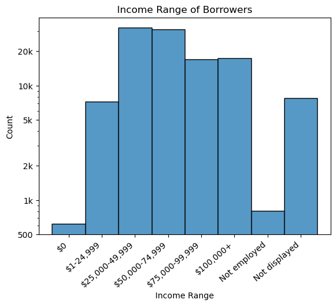

```python
base_color = sb.color_palette()[0]
sb.histplot(data=loan_data, x='IncomeRange', color=base_color)
plt.xlabel('Income Range')
plt.xticks(rotation=40, ha='right', fontsize=10)

plt.yscale('log')
plt.yticks([500, 1e3, 2e3, 5e3, 1e4, 2e4], [500, '1k', '2k', '5k', '10k', '20k'])
plt.ylabel('Count')
plt.title("Income Range of Borrowers");
```

Most borrowers are in the income range of ($25,000-$49,999) and ($50,000-$74,999). From the result, I can say that those in the lower middle class are more prone to borrowing as compared to higher earning borrowers.

#### Why do people borrow on Prosper?

```python
loan_data['ListingCategory'].value_counts()
```

```
Debt Consolidation    58308
NA                    16965
Other                 10494
Home Improvement       7433
Business               7189
Auto                   2572
Personal Loan          2395
Household Expenses     1996
Medical/Dental         1522
Taxes                   885
Large Purchases         876
Wedding Loans           771
Vacation                768
Student Use             756
Motorcycle              304
Engagement Ring         217
Baby&Adoption           199
Cosmetic Procedure       91
Boat                     85
Green Loans              59
RV                       52
Name: ListingCategory, dtype: int64
```

```python
listing_counts = loan_data['ListingCategory'].value_counts()
listing_order = listing_counts.index
```

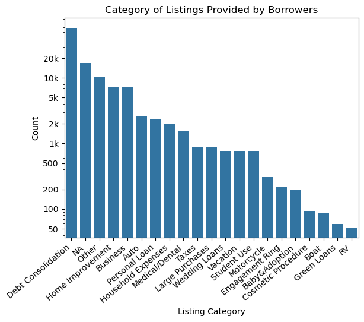

```python
sb.countplot(data=loan_data, x='ListingCategory', color=base_color, order=listing_order)
plt.xlabel('Listing Category')
plt.xticks(rotation=40, ha='right', fontsize=10)

plt.yscale('log')
plt.yticks([50,100,200,500, 1e3, 2e3, 5e3, 1e4, 2e4], [50,100,200,500, '1k', '2k', '5k', '10k', '20k'])
plt.ylabel('Count')
plt.title("Category of Listings Provided by Borrowers");
```

Debt Consolidation ranks high among the list followed by Not Available and Other(this reasons are vague). In my opinion, I think this terms should not be included in the options as investors should know the reason why a borrower needs a loan. Other reasons include home improvement and business. According to this [Forbes report](https://www.forbes.com/advisor/personal-loans/good-reasons-to-get-a-personal-loan/),our analysis resonates with the result.

#### What is the Status of Loans on Prosper?

```python
loan_data['LoanStatus'].value_counts()
```

```
Current                   56576
Completed                 38074
Chargedoff                11992
Defaulted                  5018
Past Due (1-15 days)        806
Past Due (31-60 days)       363
Past Due (61-90 days)       313
Past Due (91-120 days)      304
Past Due (16-30 days)       265
FinalPaymentInProgress      205
Past Due (>120 days)         16
Cancelled                     5
Name: LoanStatus, dtype: int64
```

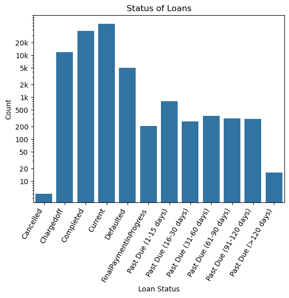

```python
sb.countplot(data=loan_data, x='LoanStatus', color=base_color)
plt.xlabel('Loan Status')
plt.xticks(rotation=60, ha='right', fontsize=10)

plt.yscale('log')
plt.yticks([10,20,50,100, 200, 500, 1e3, 2e3, 5e3, 1e4, 2e4], [10,20,50,100, 200, 500, '1k', '2k', '5k', '10k', '20k'])
plt.ylabel('Count')
plt.title("Status of Loans");
```

A good number of loans have been completed while a high number of loans were charged-off and also we have quite a number in due and defaulted loans. This doesn't seem to speak well about borrowers on Prosper as this behaviour tends to scare away investors from the platform. I had to use a log scale to properly depict the analysis.

#### Which State does most borrowers reside?

```python
state_counts = loan_data['BorrowerState'].value_counts()
state_order = state_counts.index
state_counts
```

```
CA    14717
TX     6842
NY     6729
FL     6720
IL     5921
GA     5008
OH     4197
MI     3593
VA     3278
NJ     3097
NC     3084
WA     3048
PA     2972
MD     2821
MO     2615
MN     2318
MA     2242
CO     2210
IN     2078
AZ     1901
WI     1842
OR     1817
TN     1737
AL     1679
CT     1627
SC     1122
NV     1090
KS     1062
KY      983
OK      971
LA      954
UT      877
AR      855
MS      787
NE      674
ID      599
NH      551
NM      472
RI      435
HI      409
WV      391
DC      382
MT      330
DE      300
VT      207
AK      200
SD      189
IA      186
WY      150
ME      101
ND       52
Name: BorrowerState, dtype: int64
```

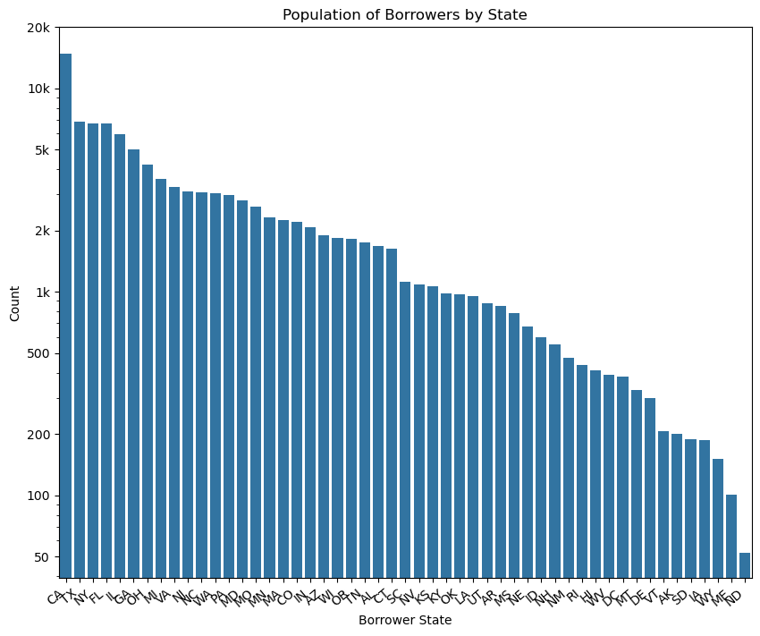

```python
plt.figure(figsize=(10,8))
sb.countplot(data=loan_data, x='BorrowerState', color=base_color, order=state_order)
plt.xlabel('Borrower State')
plt.xticks(rotation=40, ha='right', fontsize=10)
plt.yscale('log')
plt.yticks([50,100,200,500, 1e3, 2e3, 5e3, 1e4, 2e4], [50,100,200,500, '1k', '2k', '5k', '10k', '20k'])
plt.ylabel('Count')
plt.title("Population of Borrowers by State");
```

Most of Borrowers on Prosper reside in California. [Report](https://meric.mo.gov/data/cost-living-data-series) states California as one of the states in the US with a high cost living. Hence, my assumption as to why more people need to borrow to live well. In the previous analysis on income, most of the borrower's income fall between the ($25,000 - $49,999) and ($50,000 - $74,999) range. This provides more information on the borrowing pattern.

```python
loan_data['DebtToIncomeRatio']
```

```
0         0.17
1         0.18
2         0.06
3         0.15
4         0.26
          ...
113932    0.13
113933    0.11
113934    0.51
113935    0.48
113936    0.23
Name: DebtToIncomeRatio, Length: 113937, dtype: float64
```

```python
def log_trans(x, inverse=False):
    if not inverse:
        return np.log10(x)
    else:
        return np.power(10,x)
```

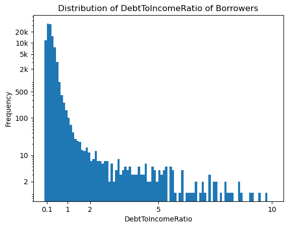

```python
bins = np.arange(0, 10+0.1, 0.1)
ticks = [0.1,1,2,5, 10]

labels = ['{}'.format(v) for v in ticks]

plt.hist(data=loan_data, x='DebtToIncomeRatio', bins=bins)
plt.ylabel('Frequency')
plt.yscale('log')
plt.yticks([2, 10, 100,500, 2e3, 5e3, 1e4, 2e4], [2, 10, 100,500, '2k', '5k', '10k', '20k'])


plt.xticks(ticks, labels)
plt.xlabel('DebtToIncomeRatio')
plt.title("Distribution of DebtToIncomeRatio of Borrowers");
```

The distribution is positively right-skewed. This implies a low debt-to-income ratio and it makes borrowing more attractive because borrower will have sufficient income to service their debt. [source] (https://www.investopedia.com/terms/d/dti.asp)

### Discuss the distribution(s) of your variable(s) of interest. Were there any unusual points? Did you need to perform any transformations?

> For most of my plots, I had to plot a vertical chart to display the chart axis labels properly and also perform log transformation on the axis to accomodate both small and large values and prevent the occurence of lie factor. Most of the variables of interest were positively right-skewed.

### Of the features you investigated, were there any unusual distributions? Did you perform any operations on the data to tidy, adjust, or change the form of the data? If so, why did you do this?

> When I initially created the plots, it was distorted due to a huge difference in the counts. Applying a log transform to the scale helped to make sense of the visual.

> While I was exploring the dataset, I noticed wrong use of datatypes and inconsistent variable naming. So, I cleaned the dataset by renaming columns and assigning the correct datatype to variables before visualization. I performed this action to make my visualization present the appropriate information.

## Bivariate Exploration

According to this [source] (https://www.wellsfargo.com/financial-education/credit-management/five-c/#:~:text=Income%20amount%2C%20stability%2C%20and%20type,DTI), I will be investigating relationships between the features in the dataset. First, I will look at the pairwise correlation between features of interest.

```python
num_vars = ['BorrowerAPR', 'BorrowerRate', 'CreditScoreRangeUpper', 'MonthlyLoanPayment', 'EstimatedReturn',
            'StatedMonthlyIncome', 'DebtToIncomeRatio', 'ProsperRating (numeric)', 'Term']
```

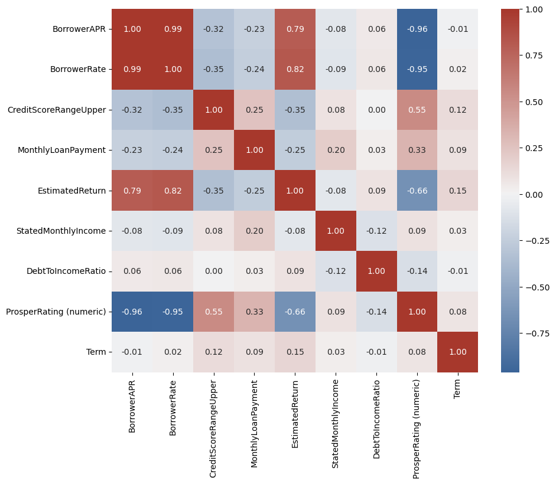

```python
# correlation plot for all loans
plt.figure(figsize=[10,8])

# custom diverging palette
cmap = sb.diverging_palette(250, 15, s=75, l=40, n=9, center="light", as_cmap=True)

sb.heatmap(loan_data[num_vars].corr(), annot=True, fmt='.2f', center=0, cmap=cmap);
```

#### Do loans with shorter or longer terms have high yield and return?

I am investigating both EstimatedEffectiveYield and EstimatedReturn as they are both ways of measuring profitability of an investment.

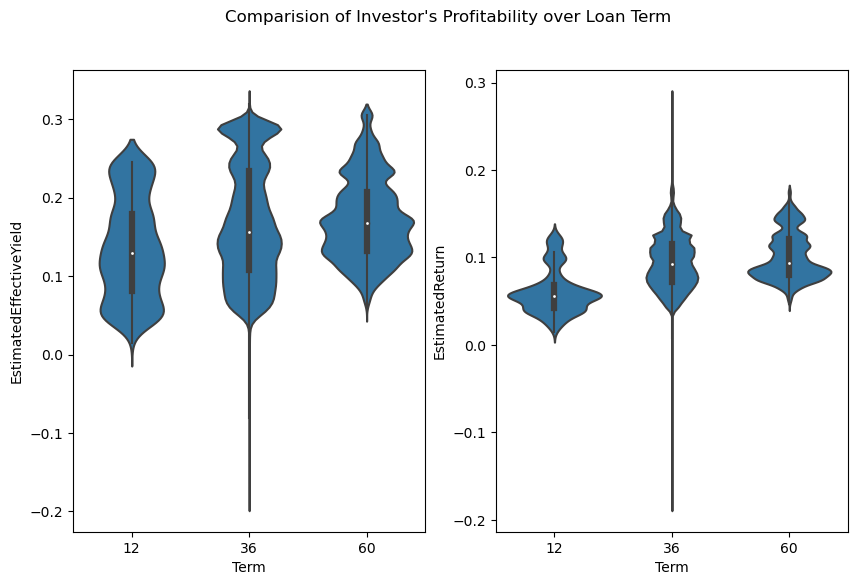

```python
fig = plt.figure(figsize=(10,6))
plt.subplot(1,2,1)
sb.violinplot(data=loan_data, x='Term', y='EstimatedEffectiveYield', color=base_color)
plt.subplot(1,2,2)
sb.violinplot(data=loan_data, x='Term', y='EstimatedReturn', color=base_color)
fig.suptitle("Comparision of Investor's Profitability over Loan Term");
```